# Project 3 - Wallace

Brandon Wallace

2022-11-22

# Introduction

This project predicts wine quality based a variety of wine properties. This markdown file contains the analysis process from start to finish.

### Findings

This report found that a random forest model performed best. The random forest model was able to predict whether or not a wine was of good quality or of bad quality with only a 0.165 misclassification rate on unseen test data. The most important predictors of quality were volatile acidity and percentage of the volume of alcohol.

### Dataset

This dataset contains 6,497 observations. Each observation is a wine. There are 11 predictor variables. The response variable is a class - either “Good” or “Bad” wine.

```r
wineQuality <- read.csv("~/Carnegie Mellon - Statistical Learning/Projects/wineQuality.csv",  stringsAsFactors=TRUE)

summary(wineQuality)
```

```
##     fix.acid         vol.acid          citric           sugar
##  Min.   : 3.800   Min.   :0.0800   Min.   :0.0000   Min.   : 0.600
##  1st Qu.: 6.400   1st Qu.:0.2300   1st Qu.:0.2500   1st Qu.: 1.800
##  Median : 7.000   Median :0.2900   Median :0.3100   Median : 3.000
##  Mean   : 7.215   Mean   :0.3397   Mean   :0.3186   Mean   : 5.443
##  3rd Qu.: 7.700   3rd Qu.:0.4000   3rd Qu.:0.3900   3rd Qu.: 8.100
##  Max.   :15.900   Max.   :1.5800   Max.   :1.6600   Max.   :65.800
##    chlorides          free.sd          total.sd        density
##  Min.   :0.00900   Min.   :  1.00   Min.   :  6.0   Min.   :1.00
##  1st Qu.:0.03800   1st Qu.: 17.00   1st Qu.: 77.0   1st Qu.:2.00
##  Median :0.04700   Median : 29.00   Median :118.0   Median :2.00
##  Mean   :0.05603   Mean   : 30.53   Mean   :115.7   Mean   :1.97
##  3rd Qu.:0.06500   3rd Qu.: 41.00   3rd Qu.:156.0   3rd Qu.:2.00
##  Max.   :0.61100   Max.   :289.00   Max.   :440.0   Max.   :3.00
##        pH          sulphates         alcohol       label
##  Min.   :2.720   Min.   :0.2200   Min.   : 8.00   BAD :2384
##  1st Qu.:3.110   1st Qu.:0.4300   1st Qu.: 9.50   GOOD:4113
##  Median :3.210   Median :0.5100   Median :10.30
##  Mean   :3.219   Mean   :0.5313   Mean   :10.49
##  3rd Qu.:3.320   3rd Qu.:0.6000   3rd Qu.:11.30
##  Max.   :4.010   Max.   :2.0000   Max.   :14.90
```

```r
dim(wineQuality)
```

```
## [1] 6497   12
```

### Exploratory Data Analysis

I removed two outlier data points. One in sugar which was more than twice the size than the next largest value and one in free.sd which was also nearly twice the size of the next largest value. There is little evidence of multicollinearity. There is some strong relation between free.sd and total.sd since these are both measures of sulfur dioxide.

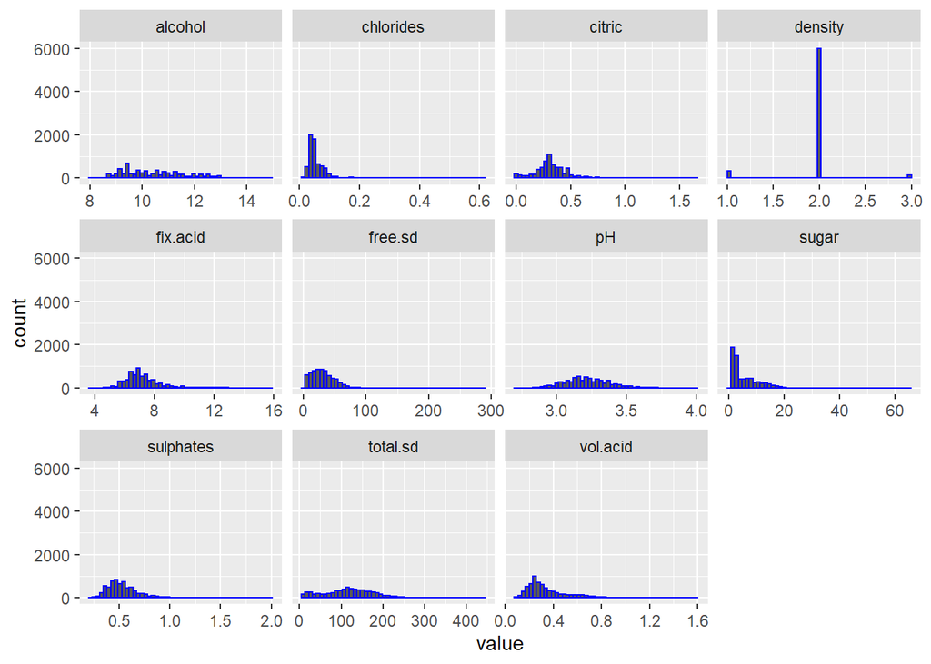

```r
suppressWarnings(suppressPackageStartupMessages(library(tidyverse)))
distribution_check <- wineQuality  %>% select(-label) %>% gather()

ggplot(data = distribution_check, mapping=aes(value)) +
  geom_histogram(color='blue', bins = 50) +
  facet_wrap(~key, scales = 'free_x')
```

```r
head(sort(wineQuality$sugar,decreasing=TRUE),n=10)
```

```
##  [1] 65.80 31.60 31.60 26.05 26.05 23.50 22.60 22.00 22.00 20.80
```

```r
head(sort(wineQuality$free.sd,decreasing=TRUE),n=10)
```

```
##  [1] 289.0 146.5 138.5 131.0 128.0 124.0 122.5 118.5 112.0 110.0
```

```r
head(sort(wineQuality$total.sd,decreasing=TRUE),n=10)
```

```
##  [1] 440.0 366.5 344.0 313.0 307.5 303.0 294.0 289.0 282.0 278.0
```

```r
df <- subset(wineQuality, wineQuality$sugar != 65.80)
```

```r
df <- subset(df, df$free.sd != 289.0)
```

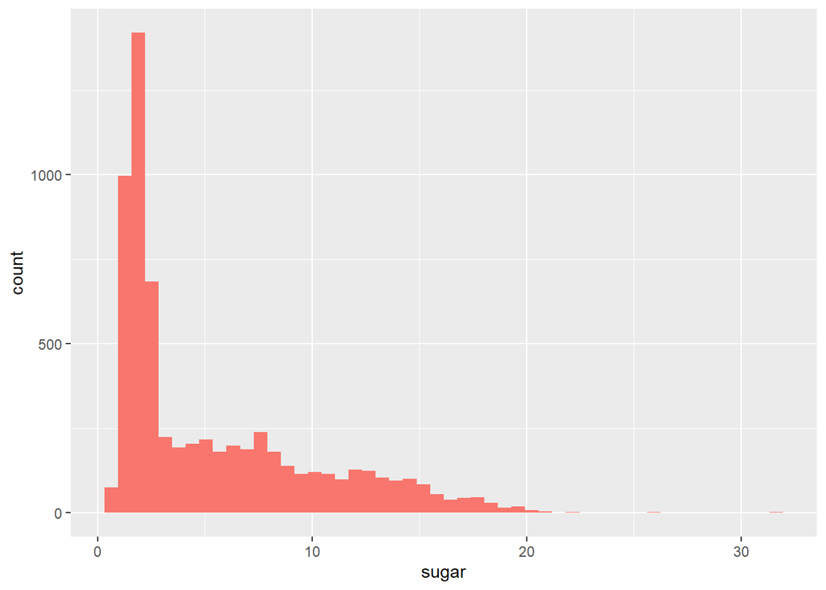

```r
ggplot(df, aes(x = sugar, fill = "red")) +
         geom_histogram(bins =50, show.legend = FALSE)
```

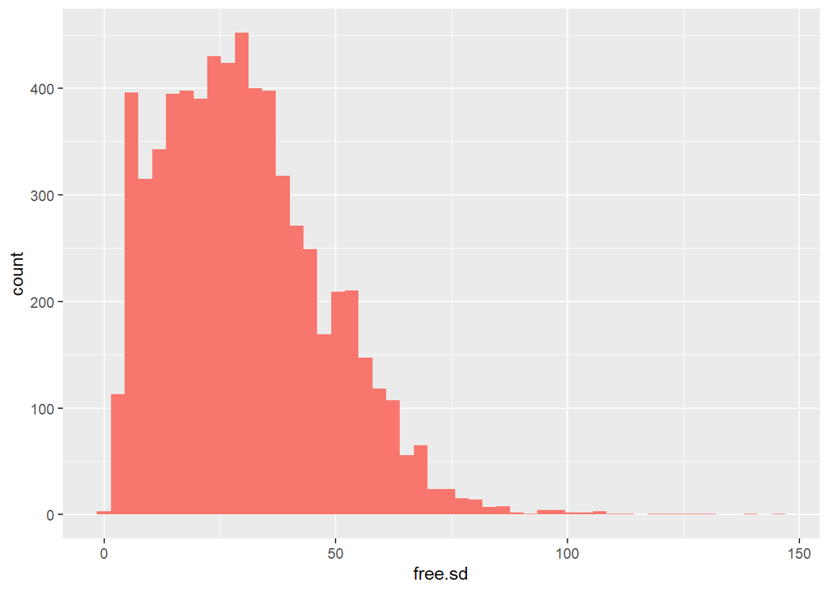

```r
ggplot(df, aes(x = free.sd, fill = "red")) +
         geom_histogram(bins =50, show.legend = FALSE)
```

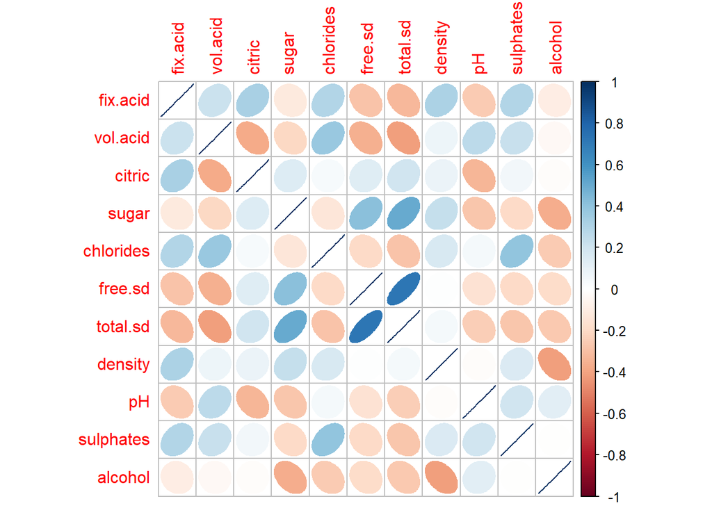

```r
suppressWarnings(suppressPackageStartupMessages(library(corrplot)))

df %>% select(-label) %>%
  cor(.) %>%
  corrplot(.,method="ellipse")
```

### Data Splitting

I split the data into predictor variables and a response variable. I then split the training data and a test data by taking a random sample of the indexes of every row in the dataframe. I used a 70/30 split. I then used the indexes to save my four new variables.

```r
set.seed(112)

resp <- df[,12]
pred <- df[,-12]

s <- sample(nrow(df),round(0.7*nrow(df)))

pred.train <- pred[s,]
pred.test <- pred[-s,]

resp.train <- resp[s]
resp.test <- resp[-s]
```

# Models

### Best GLM Logistic Regression

The Logistic Regression model averaged a misclassification rate of 0.263. In order to make a prediction on the test data, I used a class separation threshold of 0.63 because there is a class imbalance in the response variable. 63% of the label column data are good wines, which represent Class 1 probabilities. This imbalance would systemically be pulled upwards toward 1, so the threshold is adjusted. The area under the curve for the ROC is 0.742.

```r
suppressWarnings(suppressPackageStartupMessages(library(bestglm)))

log.out = glm(resp.train~., data = pred.train, family = binomial)
summary(log.out)
```

```
##
## Call:
## glm(formula = resp.train ~ ., family = binomial, data = pred.train)
##
## Deviance Residuals:
##     Min       1Q   Median       3Q      Max
## -3.3536  -0.9192   0.4564   0.8230   2.6027
##
## Coefficients:
##              Estimate Std. Error z value Pr(>|z|)
## (Intercept) -8.858254   1.109267  -7.986 1.40e-15 ***
## fix.acid     0.058248   0.038049   1.531   0.1258
## vol.acid    -4.617898   0.304258 -15.178  < 2e-16 ***
## citric      -0.775863   0.302470  -2.565   0.0103 *
## sugar        0.080135   0.009556   8.386  < 2e-16 ***
## chlorides   -0.974848   1.212752  -0.804   0.4215
## free.sd      0.015229   0.003022   5.039 4.69e-07 ***
## total.sd    -0.007815   0.001048  -7.454 9.03e-14 ***
## density     -0.446172   0.187920  -2.374   0.0176 *
## pH           0.478015   0.269199   1.776   0.0758 .
## sulphates    1.957686   0.296310   6.607 3.92e-11 ***
## alcohol      0.889553   0.042214  21.072  < 2e-16 ***
## ---
## Signif. codes:  0 '***' 0.001 '**' 0.01 '*' 0.05 '.' 0.1 ' ' 1
##
## (Dispersion parameter for binomial family taken to be 1)
##
##     Null deviance: 5990.1  on 4545  degrees of freedom
## Residual deviance: 4746.8  on 4534  degrees of freedom
## AIC: 4770.8
##
## Number of Fisher Scoring iterations: 5
```

```r
nrow(filter(df, label == "GOOD"))
```

```
## [1] 4112
```

```r
nrow(filter(df, label == "BAD"))
```

```
## [1] 2383
```

```r
nrow(filter(df, label == "GOOD")) / (nrow(filter(df, label == "GOOD")) + nrow(filter(df, label == "BAD")))
```

```
## [1] 0.6331024
```

```r
log.prob = predict(log.out, newdata = pred.test, type = "response")
log.pred = ifelse(log.prob > 0.63, "GOOD", "BAD")

t<- table(log.pred,resp.test)
t
```

```
##         resp.test
## log.pred BAD GOOD
##     BAD  534  345
##     GOOD 168  902
```

```r
cat("The misclassification rate for the logistic model is ",round((t[1,2]+t[2,1])/sum(t),3),"\n")
```

```
## The misclassification rate for the logistic model is  0.263
```

```r
cat("A sample of class 1 probilities are: ", predict(log.out, newdata = pred.test, type = "response")[1:5])
```

```
## A sample of class 1 probilities are:  0.8893614 0.3806225 0.5562216 0.9406002 0.201686
```

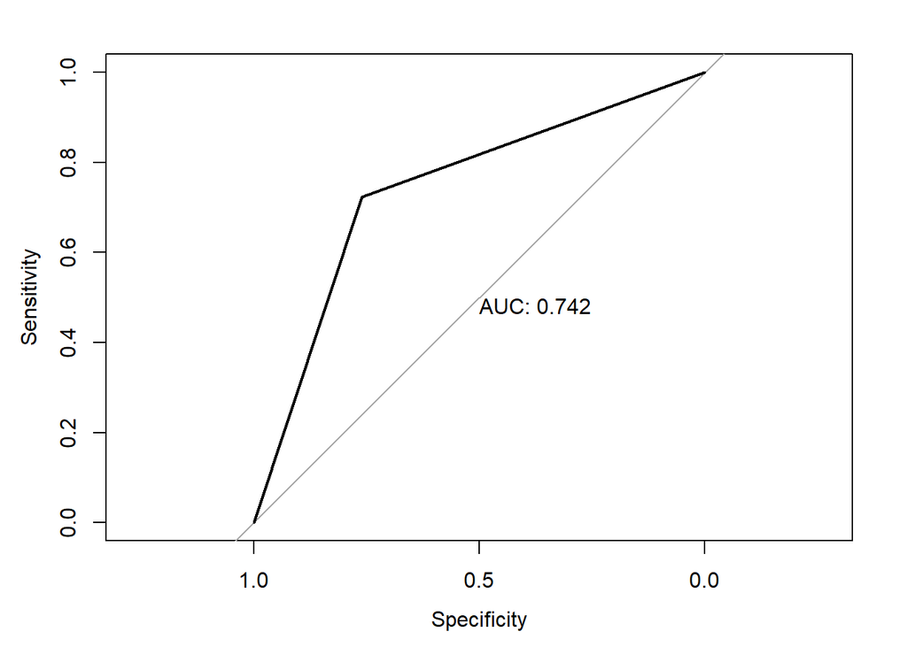

```r
suppressWarnings(suppressPackageStartupMessages(library(pROC)))

resp.test.numeric <- ifelse(resp.test == "GOOD", 1, 0)
log.pred.numeric <- ifelse(log.pred == "GOOD", 1, 0)

roc.out <- roc(resp.test.numeric ~ log.pred.numeric ,plot = TRUE, print.auc = TRUE)
```

```r
cat("AUC for logistic model: ",round(roc.out$auc,3),"\n")
```

```
## AUC for logistic model:  0.742
```

### Classification Tree

```r
suppressWarnings(suppressPackageStartupMessages(library(rpart)))

rp.out2 <- rpart(resp.train~.,data=pred.train)

success_pred <- predict(rp.out2, newdata = pred.test, type='class')

t2 <- table(success_pred, resp.test)
t2
```

```
##             resp.test
## success_pred  BAD GOOD
##         BAD   400  197
##         GOOD  302 1050
```

```r
cat("The misclassification rate for the classification tree model is ",round((t2[1,2]+t2[2,1])/sum(t2),3),"\n")
```

```
## The misclassification rate for the classification tree model is  0.256
```

```r
cat("A sample of class 1 probilities are: ", predict(rp.out2, newdata = pred.test, type='class')[1:5])
```

```
## A sample of class 1 probilities are:  2 1 2 2 1
```

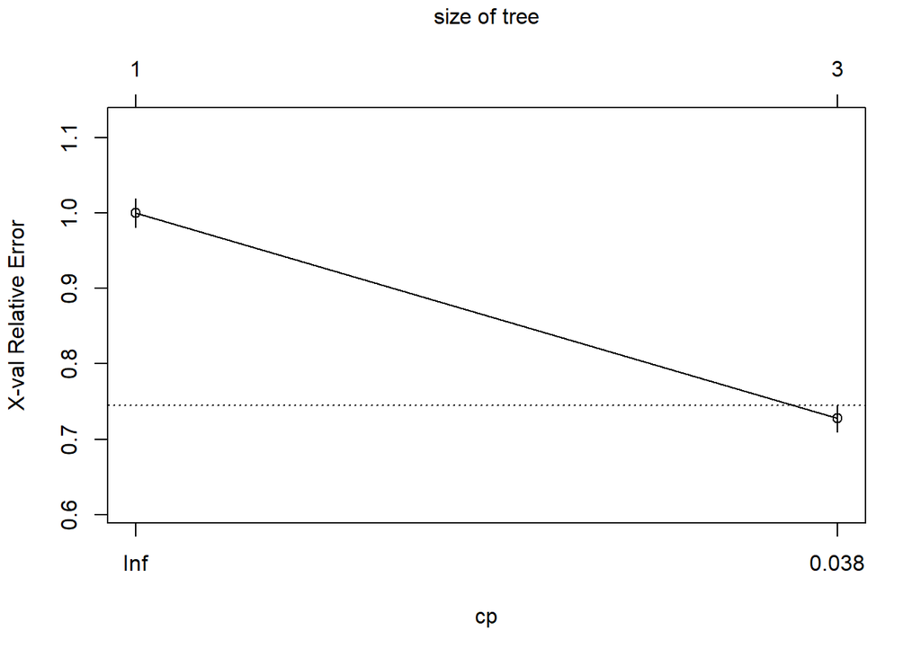

```r
plotcp(rp.out2)
```

```r
rpart.pruned <- prune(rp.out2,cp=0.038)
succcess_pred2 <- predict(rpart.pruned, newdata=pred.test, type="class")
t3 <- table(succcess_pred2, resp.test)
t3
```

```
##               resp.test
## succcess_pred2  BAD GOOD
##           BAD   400  197
##           GOOD  302 1050
```

```r
cat("The misclassification rate for the pruned tree model is ",round((t3[1,2]+t3[2,1])/sum(t3),3),"\n")
```

```
## The misclassification rate for the pruned tree model is  0.256
```

```r
cat("A sample of class 1 probilities are: ", predict(rpart.pruned, newdata = pred.test, type='class')[1:5])
```

```
## A sample of class 1 probilities are:  2 1 2 2 1
```

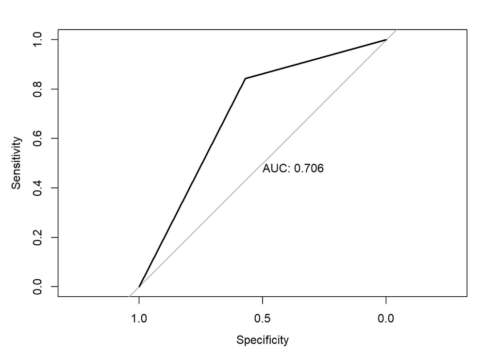

```r
suppressWarnings(suppressPackageStartupMessages(library(rpart.plot)))
resp.test.numeric <- ifelse(resp.test == "GOOD", 1, 0)
success_pred_numeric <- ifelse(success_pred == "GOOD", 1, 0)

roc.out2 <- roc(resp.test.numeric ~ success_pred_numeric ,plot = TRUE, print.auc = TRUE)
```

```r
cat("AUC for classification tree model: ",round(roc.out2$auc,3),"\n")
```

```
## AUC for classification tree model:  0.706
```

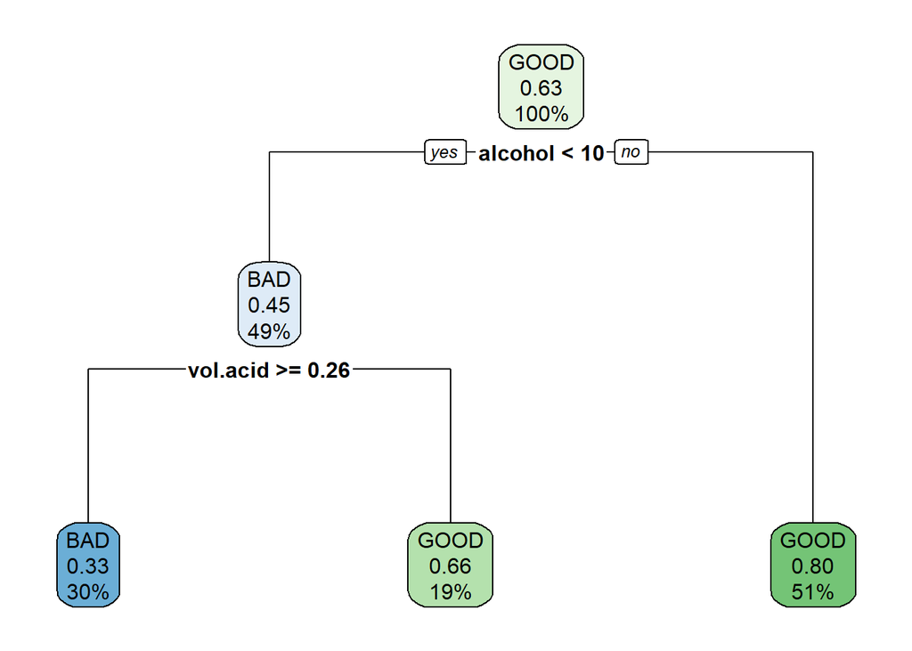

```r
rpart.plot(rp.out2)
```

### Random Forest

The Random Forest model proved most effective. It produced a misclassification rate of 0.165- the lowest of the approaches in this report. The area under the curve on the ROC plot was 0.822.

```r
set.seed(112)
suppressWarnings(suppressPackageStartupMessages(library(randomForest)))

rf.out <- randomForest(resp.train~., data = pred.train, importance = TRUE)

resp.pred <- predict(rf.out, newdata = pred.test, type = "prob")[,2]
resp.pred <- ifelse(resp.pred>0.5,"GOOD","BAD")

t4 <- table(resp.pred, resp.test)
t4
```

```
##          resp.test
## resp.pred  BAD GOOD
##      BAD   526  146
##      GOOD  176 1101
```

```r
cat("The misclassification rate for the random forrest model is ",round((t4[1,2]+t4[2,1])/sum(t4),3),"\n")
```

```
## The misclassification rate for the random forrest model is  0.165
```

```r
cat("A sample of class 1 probilities are: ", predict(rf.out, newdata = pred.test, type = "prob")[1:5])
```

```
## A sample of class 1 probilities are:  0.034 0.672 0.686 0.038 0.834
```

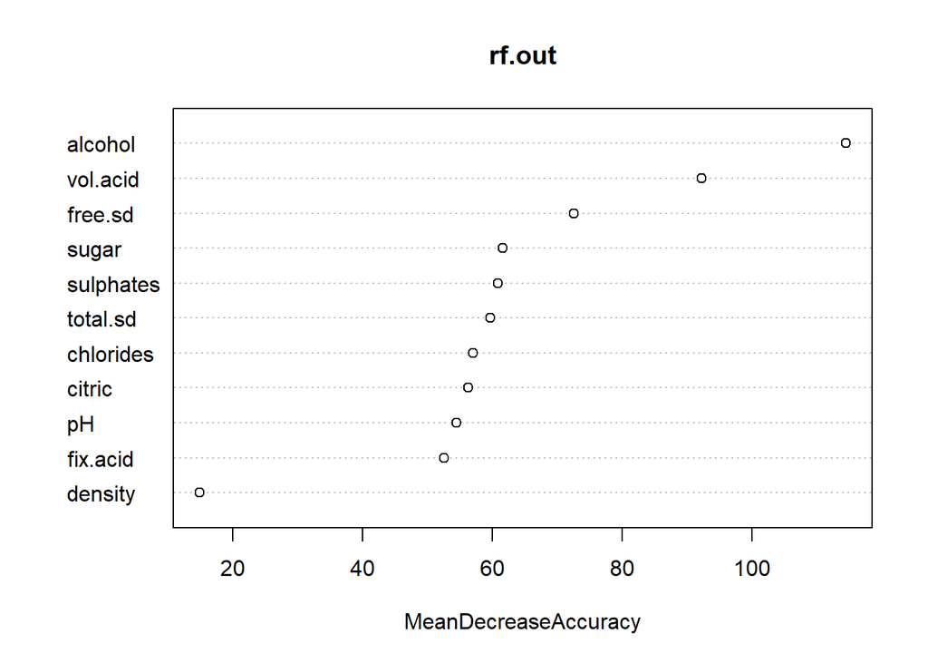

```r
varImpPlot(rf.out,type=1)
```

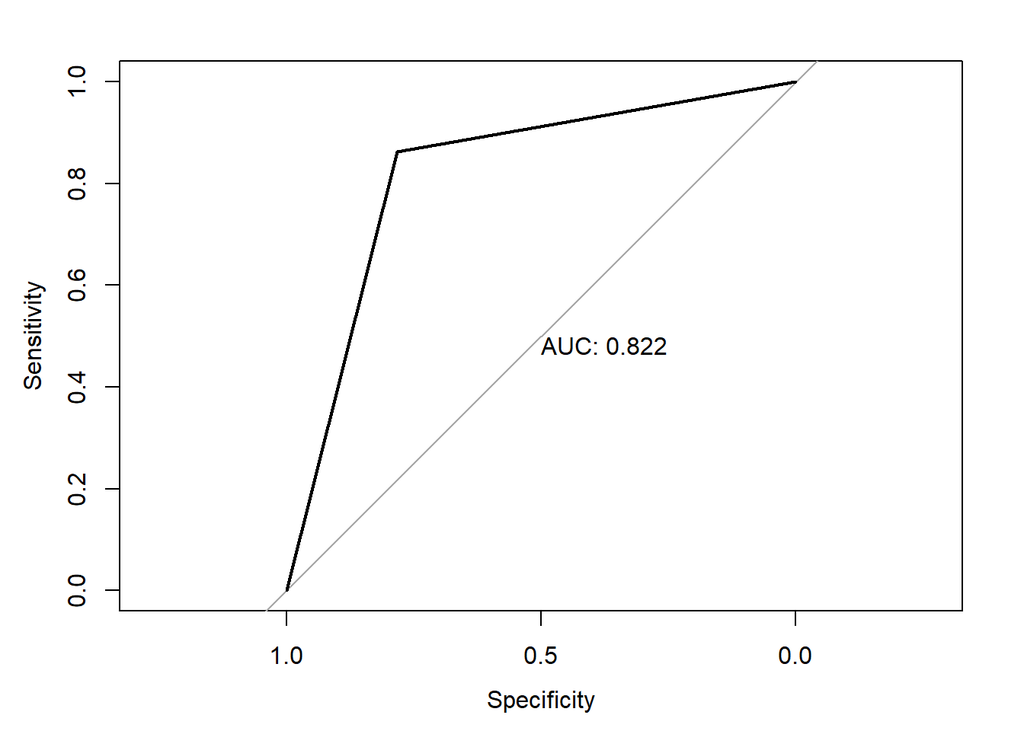

```r
resp.pred.numeric <- ifelse(resp.pred == "GOOD", 1, 0)
resp.test.numeric <- ifelse(resp.test == "GOOD", 1, 0)

roc.out3 <- roc(resp.pred.numeric ~ resp.test.numeric ,plot = TRUE, print.auc = TRUE)
```

```r
cat("AUC for random forest model is: ",round(roc.out3$auc,3),"\n")
```

```
## AUC for random forest model is:  0.822
```

### K Nearest Neighbor

The KNN model found an optimal number of nearest neighbors to be 1- i.e. the best predictor of any given point’s class was the point closest to it in space. The area under the curve in the ROC plot was 0.724.

```r
suppressWarnings(suppressPackageStartupMessages(library(FNN)))

k.max = 50
misclas.k = rep(NA,k.max)
for ( kk in 1:k.max ) {
  knn.out = knn.cv(train = pred.train, cl = resp.train, k = kk, algorithm = "brute")
  misclas.k[kk] = mean(knn.out != resp.train)
}
k.min = which.min(misclas.k)
cat("The optimal number of nearest neighbors is ",k.min,"\n")
```

```
## The optimal number of nearest neighbors is  1
```

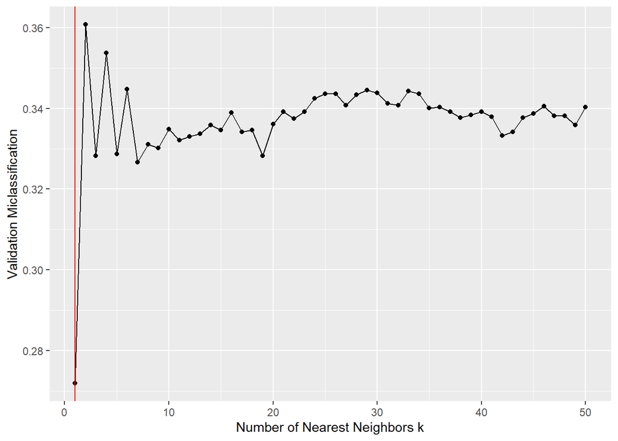

```r
ggplot(data=data.frame("k"=1:k.max,"misclass"=misclas.k),mapping=aes(x=k,y=misclass)) +
  geom_point() + geom_line() +
  xlab("Number of Nearest Neighbors k") + ylab("Validation Miclassification") +
  geom_vline(xintercept=k.min,color="red")
```

```r
knn.out = knn.cv(train=pred.train, cl=resp.train, k=k.min, algorithm="brute", prob = TRUE)
knn.pred = knn(train=pred.train,test=pred.test,cl=resp.train,k=k.min,algorithm="brute",prob=TRUE)
knn.prob = attributes(knn.pred)$prob
w = which(knn.pred=="BAD")
knn.prob[w] = 1 - knn.prob[w]
```

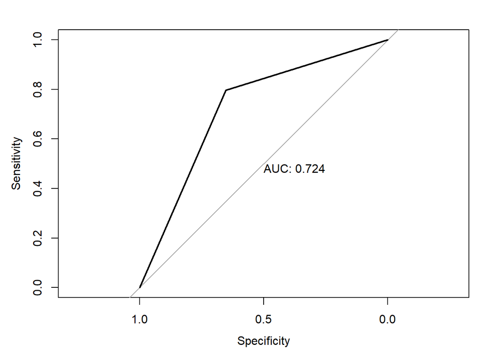

```r
roc.out4 <- roc(resp.test,knn.prob, plot = TRUE, print.auc = TRUE)
```

```r
cat("AUC for the KNN model is: ",round(roc.out4$auc,3),"\n")
```

```
## AUC for the KNN model is:  0.724
```

### Support Vector Machine

The support vector machine model did not outperform the random forest model. The linear kernel for the SVM model outperformed the polynomial and the radial kernel with a misclassification rate of 0.248. The area under the curve for the best performing kernel was 0.712.

```r
suppressWarnings(suppressPackageStartupMessages(library(e1071)))

set.seed(112)
training <- cbind(pred.train, resp.train)

tune.out = tune(svm,resp.train~., data=training, kernel="linear", ranges=list(cost=c(0.01, 0.1, 1 ,5 ,10)))

cat("The estimated optimal value for C is ",as.numeric(tune.out$best.parameters),"\n")
```

```
## The estimated optimal value for C is  1
```

```r
best.resp.pred = predict(tune.out$best.model,newdata=pred.test)
mean(best.resp.pred!=resp.test) ; table(best.resp.pred,resp.test)
```

```
## [1] 0.2478194
```

```
##               resp.test
## best.resp.pred  BAD GOOD
##           BAD   400  181
##           GOOD  302 1066
```

```r
tune.out = tune(svm,resp.train~., data=training, kernel="polynomial", ranges=list(cost=c(0.01, 0.1, 1 ,5 ,10)), degree = 2:4)

cat("The estimated optimal values for C and degree are ",as.numeric(tune.out$best.parameters),"\n")
```

```
## The estimated optimal values for C and degree are  10
```

```r
resp.pred = predict(tune.out$best.model,newdata=pred.test)
mean(resp.pred!=resp.test) ; table(resp.pred,resp.test)
```

```
## [1] 0.3175988
```

```
##          resp.test
## resp.pred  BAD GOOD
##      BAD   165   82
##      GOOD  537 1165
```

```r
tune.out = tune(svm,resp.train~., data=training, kernel="radial", ranges=list(cost=c(0.01, 0.1, 1 ,5 ,10)), gamma=10^seq(c(0.01, 0.1, 1 ,5 ,10)))

cat("The estimated optimal values for C and gamma are ",as.numeric(tune.out$best.parameters),"\n")
```

```
## The estimated optimal values for C and gamma are  5
```

```r
resp.pred = predict(tune.out$best.model,newdata=pred.test)
mean(resp.pred!=resp.test) ; table(resp.pred,resp.test)
```

```
## [1] 0.2652642
```

```
##          resp.test
## resp.pred  BAD GOOD
##      BAD   201   16
##      GOOD  501 1231
```

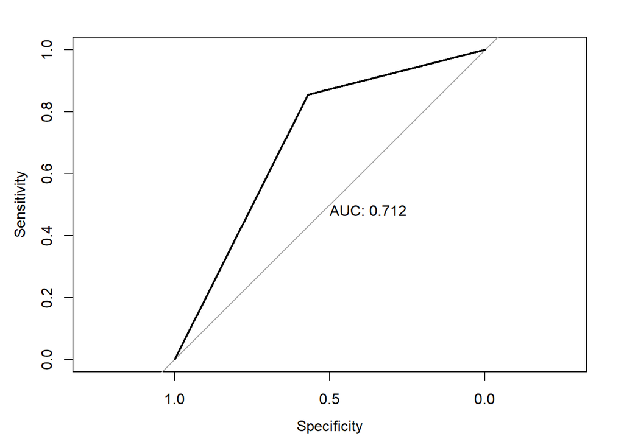

```r
resp.pred.numeric <- ifelse(best.resp.pred == "GOOD", 1, 0)
resp.test.numeric <- ifelse(resp.test == "GOOD", 1, 0)
roc.out5 <- roc(resp.test.numeric,resp.pred.numeric, plot = TRUE, print.auc = TRUE)
```

```r
cat("AUC for the KNN model is: ",round(roc.out5$auc,3),"\n")
```

```
## AUC for the KNN model is:  0.712
```

## Optimized Model

```r
TP <- t4[2,2]
FP <- t4[2,1]
TN <- t4[1,1]
FN <- t4[1,2]

SENS <- TP / (TP + FP)
SPEC <- TN / (TN + FP)

YOUD_J <- (SENS + SPEC) - 1

YOUD_J
```

```
## [1] 0.6114647
```

```r
rf.out <- randomForest(resp.train~., data = pred.train, importance = TRUE)

resp.pred <- predict(rf.out, newdata = pred.test, type = "prob")[,2]
resp.pred <- ifelse(resp.pred>YOUD_J,"GOOD","BAD")

t5 <- table(resp.pred, resp.test)
t5
```

```
##          resp.test
## resp.pred  BAD GOOD
##      BAD   580  232
##      GOOD  122 1015
```

```r
cat("The misclassification rate for the new random forrest model is ",round((t4[1,2]+t4[2,1])/sum(t4),3),"\n")
```

```
## The misclassification rate for the new random forrest model is  0.165
```

```r
cat("A sample of class 1 probilities are: ", predict(rf.out, newdata = pred.test, type = "prob")[1:5])
```

```
## A sample of class 1 probilities are:  0.052 0.722 0.694 0.032 0.844
```